# Reproducible Research: Data Quality & Analysis of Synthetic Sleep and Wellbeing Data

Reproducible Research Pipeline (synthetic demonstration)

2026-10-14

> **All data in this report is SYNTHETIC and fictional.** It was generated by `R/generate_data.R` for the sole purpose of demonstrating a reproducible data-quality and analysis workflow. It does not describe real people and must not be interpreted as empirical evidence about sleep or wellbeing.

# 1 Introduction

This report demonstrates a fully reproducible data-analysis workflow in R. We take a deliberately messy synthetic dataset of hypothetical sleep patterns and self-reported wellbeing, validate its quality, clean it with transparent and documented functions, and then produce descriptive statistics, frequency tables, correlations and publication-style figures.

# 2 Methodology

The workflow is organised as independent, testable R functions:

- **Generation** (`R/generate_data.R`) — creates a reproducible synthetic dataset (`set.seed(42)`) in which wellbeing genuinely depends on sleep, stress, exercise and caffeine, and then *injects* realistic data-quality problems (missing values, duplicates, inconsistent labels, impossible values).
- **Validation** (`R/validate.R`) — inspects the raw data without modifying it: missing values, exact duplicates, out-of-range entries and inconsistent category labels.
- **Cleaning** (`R/clean.R`) — operates on a *copy* of the raw data (the original is always preserved), standardises missingness, coerces numeric columns, nulls impossible values, canonicalises categories and removes duplicate rows.
- **Analysis** (`R/analysis.R`) — descriptive statistics, `janitor::tabyl` frequency tables and Pearson correlations with hypothesis tests.
- **Figures** (`R/figures.R`) — `ggplot2` publication-style graphics.
- **Tests** (`tests/testthat/`) — automated `testthat` tests on tiny datasets with known expected results.

## 2.1 Raw data quality

```r
knitr::kable(report$missing, caption = "Missing values per column (raw data)")
```

Missing values per column (raw data)

| variable | missing | pct_missing |
| --- | --- | --- |
| wellbeing_score | 50 | 4.90 |
| sleep_hours | 41 | 4.02 |
| caffeine_cups | 30 | 2.94 |
| mood | 30 | 2.94 |
| age | 20 | 1.96 |
| participant_id | 0 | 0.00 |
| survey_date | 0 | 0.00 |
| gender | 0 | 0.00 |
| sleep_quality | 0 | 0.00 |
| screen_time_hours | 0 | 0.00 |
| exercise_days_per_week | 0 | 0.00 |
| stress_level | 0 | 0.00 |

```r
knitr::kable(report$out_of_range, caption = "Out-of-range / invalid numeric entries (raw data)")
```

Out-of-range / invalid numeric entries (raw data)

| variable | n_invalid | lower | upper |
| --- | --- | --- | --- |
| age | 4 | 0 | 120 |
| sleep_hours | 9 | 0 | 24 |
| caffeine_cups | 2 | 0 | 30 |
| screen_time_hours | 0 | 0 | 24 |
| exercise_days_per_week | 4 | 0 | 7 |
| stress_level | 0 | 1 | 10 |
| wellbeing_score | 5 | 0 | 100 |

```r
knitr::kable(head(report$gender_labels, 10), caption = "Raw gender labels (inconsistent)")
```

Raw gender labels (inconsistent)

| label | n |
| --- | --- |
| Female | 406 |
| Male | 362 |
| MALE | 38 |
| m | 36 |
| M | 34 |
| F | 33 |
| female | 33 |
| Other | 29 |
| male | 25 |
| f | 24 |

```r
cat("Exact duplicate rows detected:", report$n_duplicate_rows, "\n")
```

```
## Exact duplicate rows detected: 40
```

## 2.2 Effect of cleaning

```r
tibble(
  stage = c("raw", "cleaned"),
  rows  = c(nrow(raw), nrow(cleaned))
) %>% knitr::kable(caption = "Row counts before and after cleaning")
```

Row counts before and after cleaning

| stage | rows |
| --- | --- |
| raw | 1020 |
| cleaned | 1000 |

# 3 Results

## 3.1 Descriptive statistics

```r
knitr::kable(descriptive_stats(cleaned, num_cols),
             caption = "Descriptive statistics (cleaned data)")
```

Descriptive statistics (cleaned data)

| variable | n | missing | mean | sd | median | min | max |
| --- | --- | --- | --- | --- | --- | --- | --- |
| age | 976 | 24 | 35.08 | 11.19 | 35 | 0.0 | 77.0 |
| caffeine_cups | 967 | 33 | 1.93 | 1.34 | 2 | 0.0 | 7.0 |
| exercise_days_per_week | 996 | 4 | 1.97 | 1.43 | 2 | 0.0 | 7.0 |
| screen_time_hours | 1000 | 0 | 4.97 | 2.02 | 5 | 0.0 | 11.0 |
| sleep_hours | 952 | 48 | 6.99 | 1.18 | 7 | 3.5 | 11.3 |
| stress_level | 1000 | 0 | 5.02 | 2.03 | 5 | 1.0 | 10.0 |
| wellbeing_score | 945 | 55 | 51.81 | 12.28 | 52 | 14.0 | 91.0 |

## 3.2 Frequency tables

```r
knitr::kable(frequency_table(cleaned, gender), caption = "Gender")
```

Gender

| gender | n | percent |
| --- | --- | --- |
| Female | 489 | 48.9% |
| Male | 482 | 48.2% |
| Other | 29 | 2.9% |

```r
knitr::kable(frequency_table(cleaned, sleep_quality), caption = "Sleep quality")
```

Sleep quality

| sleep_quality | n | percent |
| --- | --- | --- |
| Poor | 113 | 11.3% |
| Fair | 239 | 23.9% |
| Good | 302 | 30.2% |
| Excellent | 346 | 34.6% |

## 3.3 Correlations

```r
knitr::kable(round(correlation_matrix(cleaned, num_cols), 2),
             caption = "Pearson correlation matrix (cleaned data)")
```

Pearson correlation matrix (cleaned data)

|  | age | sleep_hours | caffeine_cups | screen_time_hours | exercise_days_per_week | stress_level | wellbeing_score |
| --- | --- | --- | --- | --- | --- | --- | --- |
| age | 1.00 | 0.01 | 0.08 | 0.01 | 0.01 | -0.01 | -0.01 |
| sleep_hours | 0.01 | 1.00 | -0.06 | 0.01 | -0.04 | -0.02 | 0.50 |
| caffeine_cups | 0.08 | -0.06 | 1.00 | -0.01 | 0.03 | 0.01 | -0.16 |
| screen_time_hours | 0.01 | 0.01 | -0.01 | 1.00 | -0.05 | -0.03 | 0.04 |
| exercise_days_per_week | 0.01 | -0.04 | 0.03 | -0.05 | 1.00 | -0.01 | 0.23 |
| stress_level | -0.01 | -0.02 | 0.01 | -0.03 | -0.01 | 1.00 | -0.48 |
| wellbeing_score | -0.01 | 0.50 | -0.16 | 0.04 | 0.23 | -0.48 | 1.00 |

```r
key <- bind_rows(
  cor_test_pair(cleaned, "sleep_hours", "wellbeing_score"),
  cor_test_pair(cleaned, "stress_level", "wellbeing_score"),
  cor_test_pair(cleaned, "exercise_days_per_week", "wellbeing_score")
)
knitr::kable(key, caption = "Key correlations with wellbeing (with p-values)")
```

Key correlations with wellbeing (with p-values)

| x | y | method | n | estimate | statistic | p_value |
| --- | --- | --- | --- | --- | --- | --- |
| sleep_hours | wellbeing_score | pearson | 901 | 0.5028662 | 17.443575 | 0 |
| stress_level | wellbeing_score | pearson | 945 | -0.4844392 | -17.004894 | 0 |
| exercise_days_per_week | wellbeing_score | pearson | 941 | 0.2337977 | 7.368505 | 0 |

## 3.4 Figures

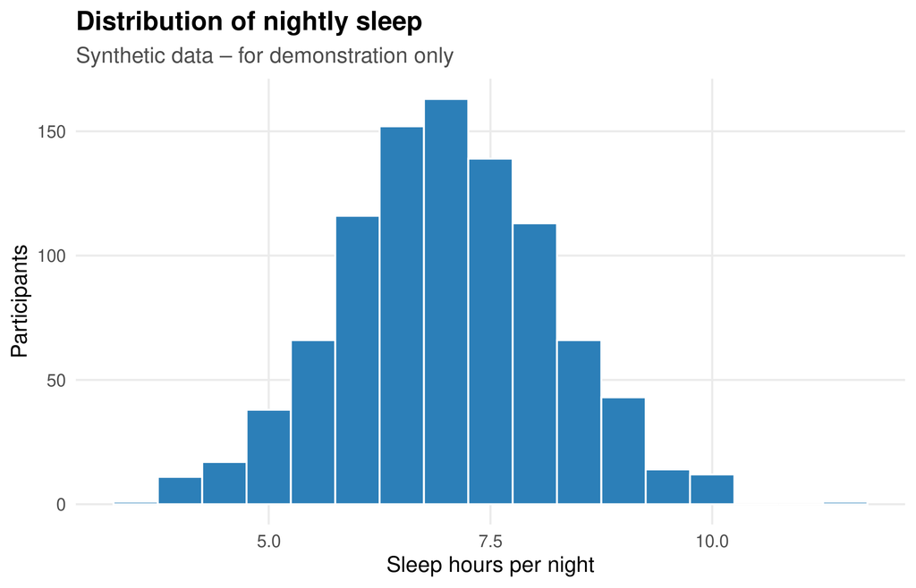

```r
fig_sleep_hist(cleaned)
```

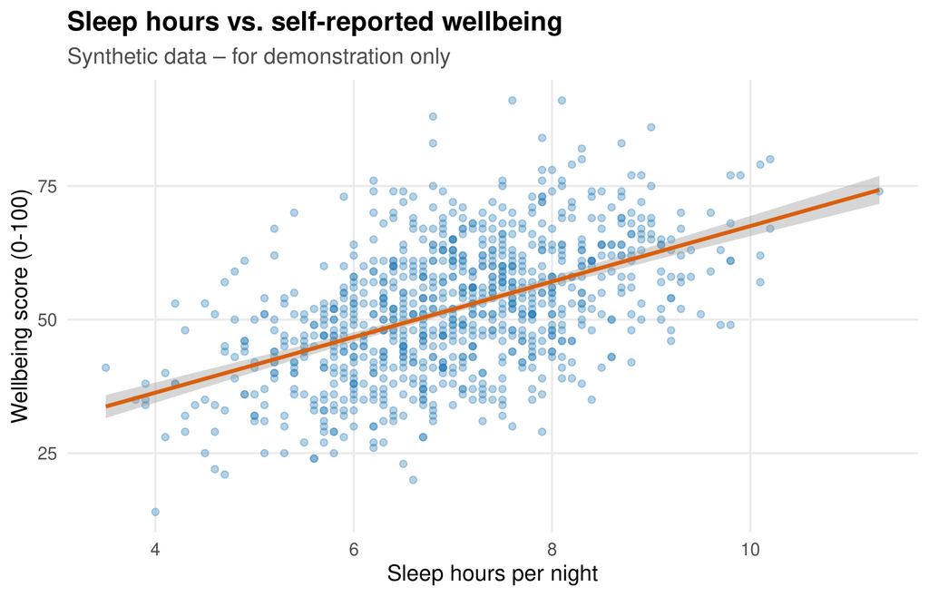

```r
fig_sleep_wellbeing(cleaned)
```

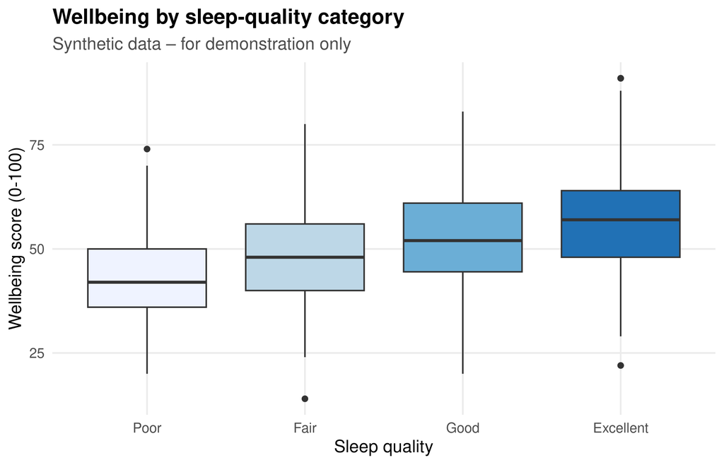

```r
fig_wellbeing_by_quality(cleaned)
```

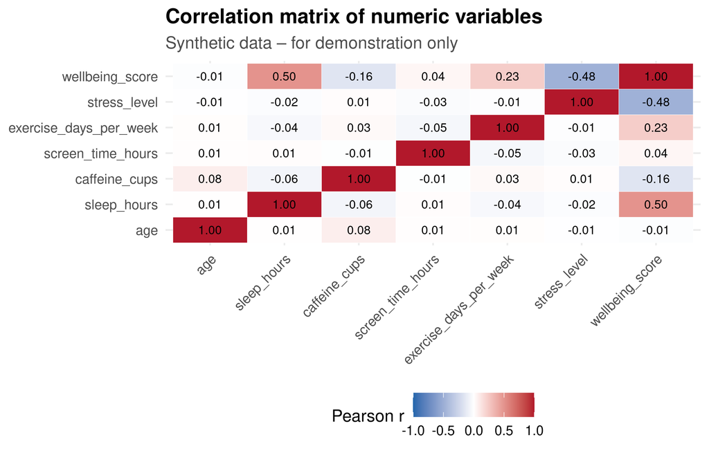

```r
fig_corr_heatmap(cleaned, num_cols)
```

# 4 Limitations

- **The data is entirely synthetic.** Relationships shown here were built into the data-generating process by construction; they are **not** evidence about real human sleep or wellbeing.
- Cleaning decisions (valid ranges, label mappings) are explicit assumptions defined in `R/clean.R`; different assumptions would yield different results.
- Invalid and missing values are set to `NA` rather than imputed, so analyses use pairwise-complete observations and sample sizes vary across correlations.
- Correlation does not imply causation; no causal claims are made.
- No real participants, institutions, supervisors or publications are involved.